# 第24回 事前学習

作者

J22069 野倉悠正

# フロントエンドのポートをバックエンドに統合する

今まで開発環境ではフロントエンドとバックエンドのポートを分けていた（フロントエンドは3000番ポート、バックエンドは5000番ポート）が、本番公開（デプロイ）時には一つにまとめることができる。

**開発環境で２つのポートが使用される理由**

開発環境では、Reactの開発サーバーが**コードを変更するとすぐに画面に反映される機能（ホットリロード）**を持つため、フロントエンド専用のポートが用意されている。

## ポート統合のロジック

これを実現するには、Reactを静的ファイルとしてビルドし、Flaskから配信する形に変更する。

1. **Reactをビルド**: `npm run build`コマンドを実行すると、HTML/CSS/JSの静的ファイルが生成される。
2. **Flaskに統合**: 生成されたReactのファイルを、Flaskのフォルダ内に配置する。
3. **Flaskだけを起動**: Flaskに「APIの処理」と「Reactの画面表示」の両方を担当させる。

**開発環境（2ポート構成）**

```
graph TB
    User(ユーザー) --> |"操作・入力"| Browser{ブラウザ}
    Browser --> |表示| User
    Browser -->|localhost:3000<br>にアクセス| React[React開発サーバー]
    React -->|UI（HTML/CSS/JS）| Browser
    React -->|"APIリクエスト<br>（/api/...）"| Flask[Flaskサーバー]
    Flask -->|"データ（JSON）"| React
```

**本番環境（1ポート構成）**

```
graph TB
    User(ユーザー) --> |"操作・入力"| Browser{ブラウザ}
    Browser --> |表示| User
    Browser --> |"リクエスト<br>（ページ表示<br>とAPI）"| Flask[Flaskサーバー] --> |"静的ファイル<br>（HTML/JS/CSS）<br>とデータ（JSON）"| Browser
```

## `send_from_directory`によるReactの静的配信

**変更後**

```
/backend/__init__.py
```

```python
import os
from flask import Flask, send_from_directory
from flask_sqlalchemy import SQLAlchemy
from flask_migrate import Migrate
from flask_bcrypt import Bcrypt
from flask_cors import CORS

db = SQLAlchemy()
migrate = Migrate()
bcrypt = Bcrypt()

def create_app():
    """Application-factory function"""

    is_production = os.getenv('FLASK_ENV') != 'development'

    # 本番環境ではReactのビルドフォルダを静的フォルダとして指定
    app_kwargs = {
        'instance_relative_config': True,
    }
    if is_production:
        app_kwargs['static_folder'] = '../../frontend/build'

    app = Flask(__name__, **app_kwargs)

    # --- Basic Config ---
    app.config.from_mapping(
        SQLALCHEMY_DATABASE_URI='sqlite:///fesData.db',
        SQLALCHEMY_TRACK_MODIFICATIONS=False,
        # JWTの署名に使う秘密鍵。本番環境ではより複雑なキーに変更
        # 環境変数ファイル(.env)に移行予定
        SECRET_KEY='your-very-secret-and-secure-key'
    )

    # --- Extensions Init ---
    db.init_app(app)
    migrate.init_app(app, db)
    bcrypt.init_app(app)

    if not is_production:
        # == Development Mode (2 Ports) ==
        # React dev server (localhost:3000)からのAPIリクエストを許可
        CORS(
            app,
            resources={r"/api/*": {"origins": "http://localhost:3000"}},
            supports_credentials=True,
            allow_headers=["Content-Type", "Authorization"],
            methods=["GET", "POST", "PUT", "DELETE", "OPTIONS"]
        )

    with app.app_context():
        # --- Blueprint Registration ---
        from . import api_routes
        app.register_blueprint(api_routes.api_bp)

        if is_production:
            # == Production Mode (1 Port) ==
            # API以外のリクエストをすべてReactアプリに流すためのルート
            @app.route('/', defaults={'path': ''})
            @app.route('/<path:path>')
            def serve_react_app(path):
                if path != "" and os.path.exists(os.path.join(app.static_folder, path)):
                    return send_from_directory(app.static_folder, path)
                else:
                    return send_from_directory(app.static_folder, 'index.html')

        # --- DB Creation ---
        db.create_all()

    return app
```

**変更点**

1. `send_from_directory`: 指定したディレクトリから指定したファイルを安全に送信するためのライブラリ。ファイルのアップロード先やダウンロード元のディレクトリをアプリケーションの設定で定義し、ルーティング関数内でその設定とファイル名を指定する。
2. `is_production`: 環境の状態をブール値で保存する変数。
3. `os.getenv('FLASK_ENV')`: `FLASK_ENV`という環境変数の値を読み取り、開発時と本番時の動作モードを柔軟に切り替える。
   - **値が`'development'`の場合**: 開発モードと判断し、React開発サーバーからのAPIリクエストを許可するためにCORSを有効にする（2ポート構成）。
   - **値が`'development'`以外（未設定も含む）の場合**: 本番モードと判断する（1ポート構成）。

**環境変数とは？**

環境変数とは、**OSに保存されるキーと値のペア**のこと。`export`コマンドで設定することができる。

今回の場合は、アプリケーションの実行環境に応じて、プログラムの動作を外部から切り替えるために利用される。

```
bash
```

```bash
export FLASK_ENV=development
```

このようにして環境変数`FLASK_ENV`を`development`に設定することができる。

**キーワード引数（`**app_kwargs`）**

`app_kwargs`という設定のまとまりを`Flask`アプリを作るときに渡すための書き方。これにより、本番のときだけ`static_folder`オプションの値が追加されるようになっている。

5. `if not is_production: ...`: 開発環境の時（`is_production`が`false`）の処理。本番環境ではCORSが必要ないため、別途条件分岐で有効にしている。
6. `if is_production: ...`: 本番環境の時（`is_production`が`true`）の処理。API（`/api/...`）以外のすべてのURLアクセスを`serve_react_app`関数が受け取り、次のように処理を振り分ける。
   - アクセスされたURLに対応するファイル（例: `main.js`や画像ファイル）が存在する場合はそのファイルをそのまま返す。
   - もし対応するファイルが存在しなければ（例: `/profile`のようなReact内のページ）、Reactアプリの本体である`index.html`を返す。

**変更前**

```
/backend/__init__.py
```

```python
from flask import Flask, jsonify, request
from flask_sqlalchemy import SQLAlchemy
from flask_migrate import Migrate
from flask_bcrypt import Bcrypt
from flask_cors import CORS


db = SQLAlchemy()
migrate = Migrate()
bcrypt = Bcrypt()

def create_app():
    """Application-factory function"""
    app = Flask(__name__, instance_relative_config=True)

    # 設定の読み込み
    app.config.from_mapping(
        SQLALCHEMY_DATABASE_URI='sqlite:///fesData.db',
        SQLALCHEMY_TRACK_MODIFICATIONS=False,
        # JWTの署名に使う秘密鍵。本番環境ではより複雑なキーに変更
        SECRET_KEY='your-very-secret-and-secure-key'
    )

    # 拡張機能の初期化
    db.init_app(app)
    migrate.init_app(app, db)
    bcrypt.init_app(app)
    # flask-corsを初期化し、アプリケーション全体に適用
    CORS(
        app,
        resources={r"/api/*": {"origins": "http://localhost:3000"}},
        supports_credentials=True,
        allow_headers=["Content-Type", "Authorization"],
        methods=["GET", "POST", "PUT", "DELETE", "OPTIONS"]
    )

    with app.app_context():
        from . import api_routes
        app.register_blueprint(api_routes.api_bp)

        db.create_all()

    return app
```

## 起動時のスクリプトの変更

**変更後**

```
/package.json
```

```json
{
  "name": "shinshu-fesnav-monorepo",
  "version": "1.0.0",
  "private": true,
  "scripts": {
    "start-backend:dev": "cd backend && pipenv run flask run --host=0.0.0.0 --port=5051 --debug",
    "start-backend:prod": "cd backend && export FLASK_ENV=production && pipenv run gunicorn --workers 4 --bind 0.0.0.0:5051 \"app:create_app()\"",
    "start-react": "cd frontend && npm start",
    "build-frontend": "cd frontend && npm run build",
    "dev": "concurrently \"npm:start-backend:dev\" \"npm:start-react\"",
    "prod": "npm run build-frontend && npm run start-backend:prod"
  },
  "devDependencies": {
    "concurrently": "^8.2.2"
  }
}
```

**ノート**

関先生にサーバーの5051番ポートを開放していただいたので、念の為開発環境も同じポートで統一した。

2. `"start-backend:prod"`: 本番環境の起動スクリプト。
   - `export FLASK_ENV=production`: 環境変数を設定。
   - `pipenv run gunicorn ...`: GunicornサーバーでFlaskを起動。
3. `"prod"`: `npm run prod`コマンドの挙動の設定。
   - `npm run build-frontend`: Reactのビルド。UI部分を静的ファイルとして生成し、`../../frontend/build`ディレクトリに格納。
   - `npm run start-backend:prod`: 2.で定義した、Gunicornによる本番環境のFlaskサーバーを起動。

**変更前**

```
/package.json
```

```json
{
  "name": "shinshu-fesnav-monorepo",
  "version": "1.0.0",
  "private": true,
  "scripts": {
    "start-backend": "cd backend && pipenv run flask run --host=0.0.0.0 --port=5051 --debug",
    "start-react": "cd frontend && npm start",
    "dev": "concurrently \"npm:start-backend\" \"npm:start-react\""
  },
  "devDependencies": {
    "concurrently": "^8.2.2"
  }
}
```

## 動作確認

### 開発環境（`npm run dev`での起動）

※クリックで拡大可能です

[figure not shown]

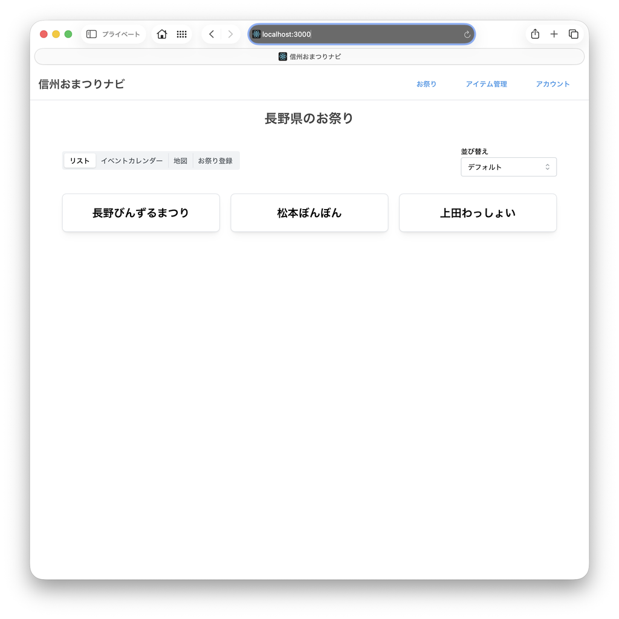

描画は`npm start`で起動したReactのサーバーによって行われているため、3000番ポートに接続すると表示される。

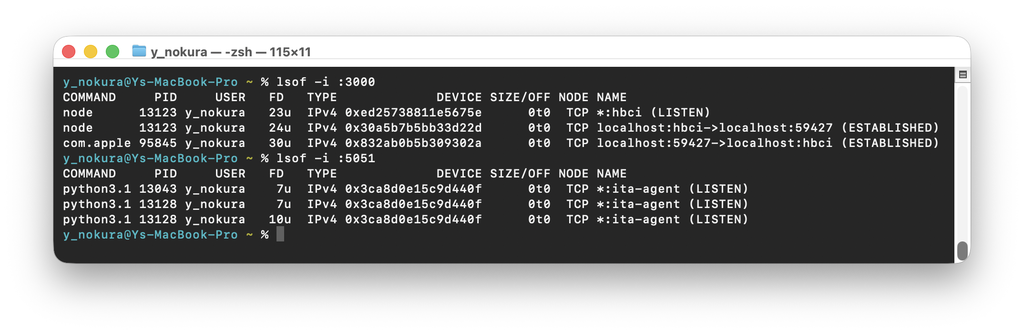

`lsof`コマンドでポートの使用状況を検索すると、上の画像の通り3000番ポートを`node`が、5051番ポートを`python3.1`が使用していることが確認できる。

### ローカル上での本番環境（`npm run prod`での起動）

**ノート**

ゼミのサーバーがエラーで接続できなかったため、一度自分のPC上で挙動を確認した。

※クリックで拡大可能です

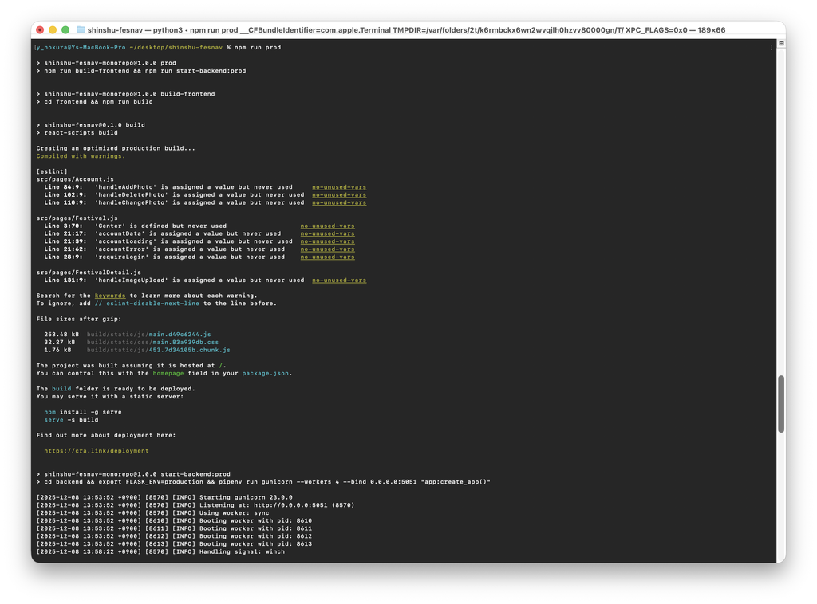

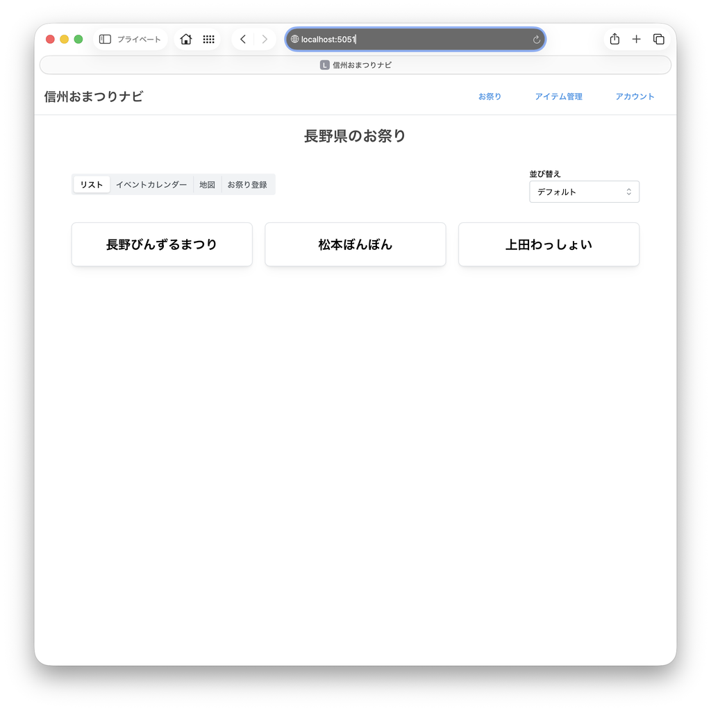

描画は`pipenv run gunicorn ...`で起動したGunicornサーバーによって行われているため、5051番ポートに接続すると表示される。

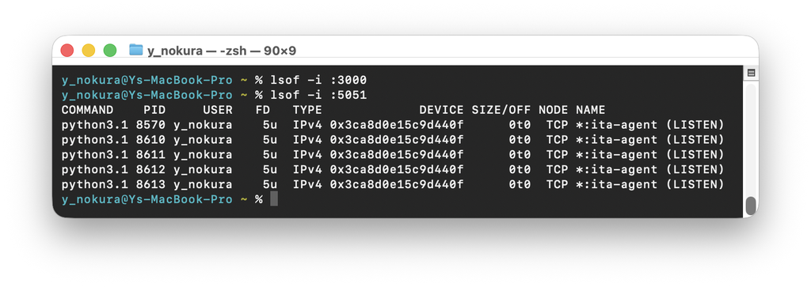

`lsof`コマンドでポートの使用状況を検索すると、上の画像の通り3000番ポートでは何も表示されないが、5051番ポートを`python3.1`が使用していることが確認できる。